## Cantinho do R

### Sobreposição de gráficos no R: um exemplinho com histogramas

ou, se preferir:

### Como sobrepor dois gráficos no R e evitar que o resultado seja uma grande bagunça!

*Marcos V. C. Vital*

Para mais material, acesse http://cantinhodor.wordpress.com/

Este documento faz parte do material que disponibilizo no meu blog, o “Cantinho do R”, e foi foi criado utilizando o software R, o programa RStudio e a linguagem Markdown. Para saber mais sobre eles, acesse:

http://www.r-project.org/

http://www.rstudio.com

http://rmarkdown.rstudio.com/

Se Você está olhando este documento e não consegue entender nada, é sinal de que tem que começar do básico com o R. Uma boa pedida é dar uma olhada na minha apostila, para só depois voltar aqui. Confira ela aqui: https://cantinhodor.wordpress.com/2015/03/28/a-boa-e-velha-apostila-basica-do-r/

Oi, pessoal!

Acho que o título já diz tudo do que se trata este script: ele fala sobre como sobrepor dois histogramas. Mais do que isso, vamos tentar ver de uma forma geral como podemos sobrepor gráficos no R, pois o que veremos aqui serve para diversas outras situações.

Assim como o [script sobre o boxplot de médias](https://cantinhodor.wordpress.com/2015/11/09/um-boxplot-de-medias-e-aprendendo-mais-sobre-graficos-no-r/), este aqui surgiu durante o curso que eu ministrei com o pessoal da [Bocaina Biologia da Conservação](http://biologiadaconservacao.com.br/) e da [ESCAS e IPÊ](http://escas.org.br/).

Não temos muito o que dizer sobre a preparação (nós vamos criar os próprios dados), então vamos deixar de conversa e colocar a mão na massa!

#### Criando dados

Para começar, vamos precisar de um conjuntinho de dados. Nós normalmente ou carregamos um conjunto de dados que eu envio junto com o script ou então carregamos dados de dentro do próprio R, [como neste exemplo](https://cantinhodor.wordpress.com/2015/10/18/graficos-no-r-algumas-sugestoes-de-aprendizado/). Então, só pra ser diferente, hoje vamos criar os nossos dados, beleza?

O R tem diversas funções que lidam com distribuições de probabilidades, e que podem ser usadas para criar dados ao acaso, seguindo a distribuição que você escolher. Se estiver curioso, veja aqui:

```r
?Distributions
```

```
## starting httpd help server ... done
```

Legal, né? Tem bastante coisa, e isso é só o que vem no R sem pacotes, com certeza tem mais coisas escondidas se você quiser procurar.

Vamos la:

```r
dados1<-rnorm(100, 5, 1)
dados2<-rnorm(100, 7, 1)
```

Pronto, aqui não tem mistério. Usamos a função `rnorm` para criar dois conjuntinho de dados. Se ficar mais curioso, brinque um pouco com a função. Os três parâmetros, na ordem, são: a quantidade de números gerados, a média e o desvio padrão.

#### Primeira olhada

Beleza, vamos lá olhar rapidamente para os histogramas, ok? Podemos fazer um de cada vez, não tem complicação:

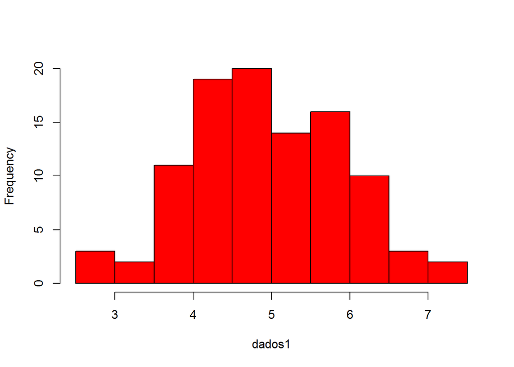

```r
#Histograma 1

hist(dados1, main=NULL, col="red")
```

E o outro:

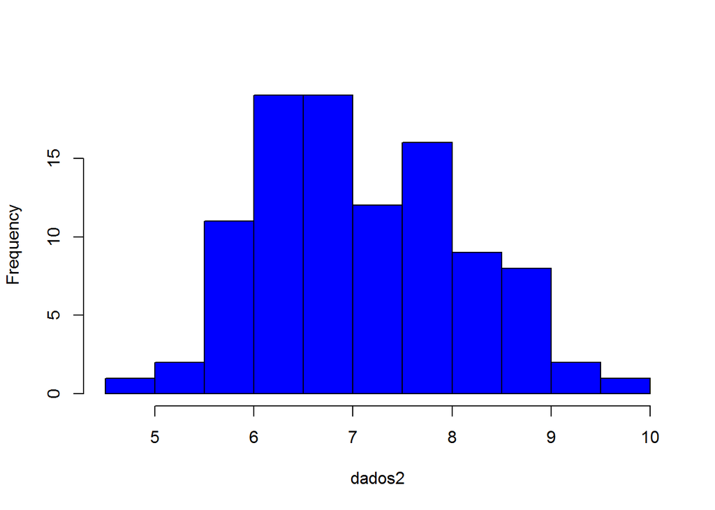

```r
#Histograma 2

hist(dados2, main=NULL, col="blue")
```

O primeiro passo para podemos visualizar os dois histogramas juntos é colocá-los na mesma escala nos eixos x e y. Vamos olhar para os dois ao mesmo tempo para facilitar, ok? Lá vai:

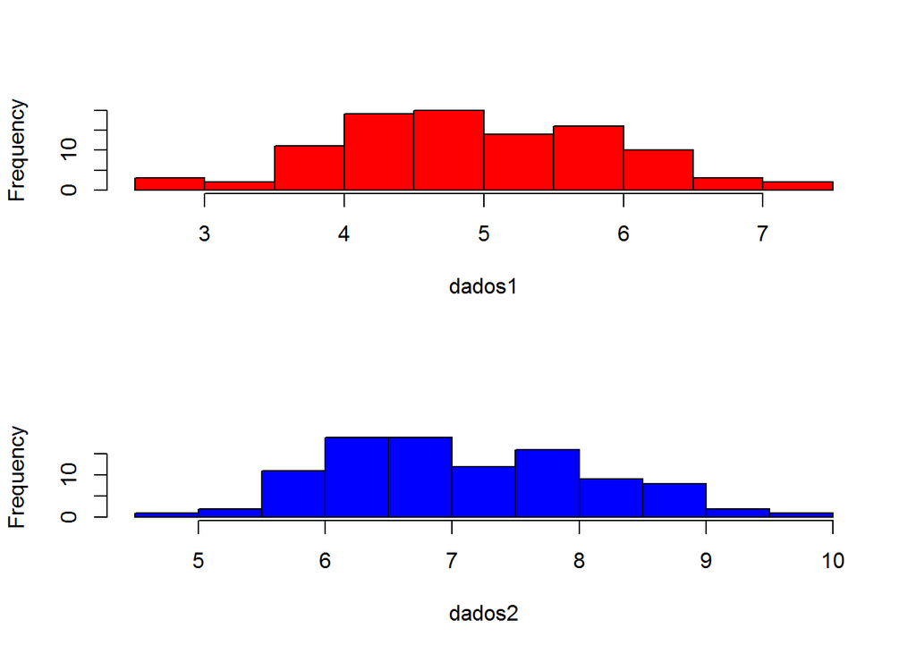

```r
par(mfrow=c(2,1))
hist(dados1, main=NULL, col="red")
hist(dados2, main=NULL, col="blue")
```

Beleza.

Note que os histogramas vão diferir em sua amplitude de valores de x e podem também apresentar variação nos valores de y (como os dados foram gerados ao acaso, a cada vez que executarmos o script teremos dois histogramas um pouco diferentes). Então é importante ficar atento para estes limites na hora de dar o próximo passo, ok?

#### Sobrepondo os histogramas

Ótimo, já temos tudo em mãos, e só nos falta de fato sobrepor os dois histogramas. É um processo bem simples, na verdade: basta plotar o primeiro (tendo o cuidado de estabelecer os limites adequados para x e y) e depois usar o argumento `add=T` ao plotar o segundo, e pronto! Fácil, né? Veja só:

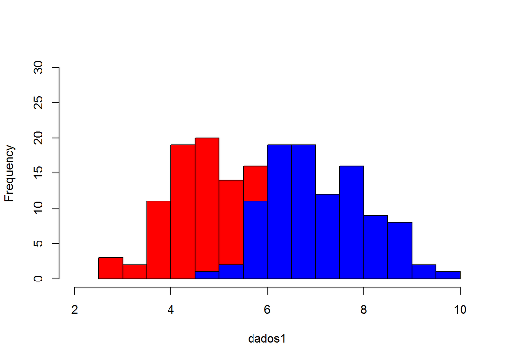

```r
#Agora os dois de uma vez:

hist(dados1, main=NULL, col="red", xlim=c(2, 10), ylim=c(0, 30))
hist(dados2, main=NULL, col="blue", add=T)
```

Aêêê, deu certo, uhu!

Peraí, mais ou menos, né? Com a sobreposição, criamos um problema: o segundo histograma acaba tampando parte do primeiro… :p

Mas é normal, e pode acontecer facilmente em situações assim. Então temos que resolver, né? Bora lá!

#### Adicionando transparência

Como é de praxe no R, com certeza podemos encontrar soluções diferentes para o nosso probleminha de sobreposição. Aqui vamos usar um simples e intuitivo: tornar as barras semi-transparentes.

O nosso ponto de partida é o comando anterior, mas vamos chamar um pacote e mudar um pouquinho a maneira de “chamar” as cores:

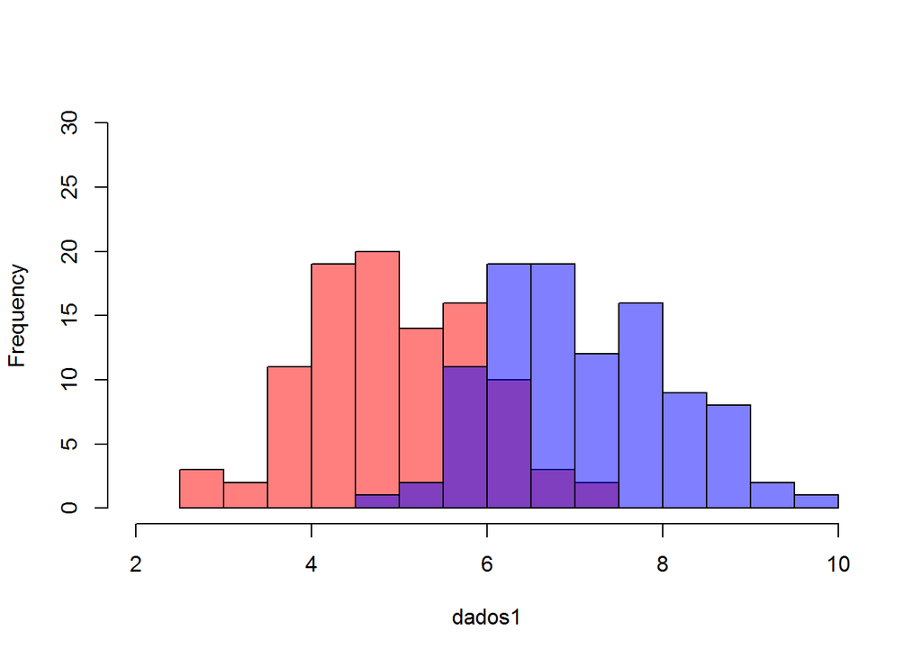

```r
#É agora que a mágica acontece:

library(scales)

hist(dados1, main=NULL, col=alpha("red", 0.5), xlim=c(2, 10), ylim=c(0, 30))
hist(dados2, main=NULL, col=alpha("blue", 0.5), add=T)
```

Simples, né? Usamos a função `alpha` do pacote `scales` para definir as cores. A função `alpha` precisa apenas de dois parâmetros: a cor, que pode ser qualquer uma que você já iria usar, e o nível de transparência, em uma escala de 0 a 1. Dá pra brincar com o valor, para ver como fica melhor. Por exemplo:

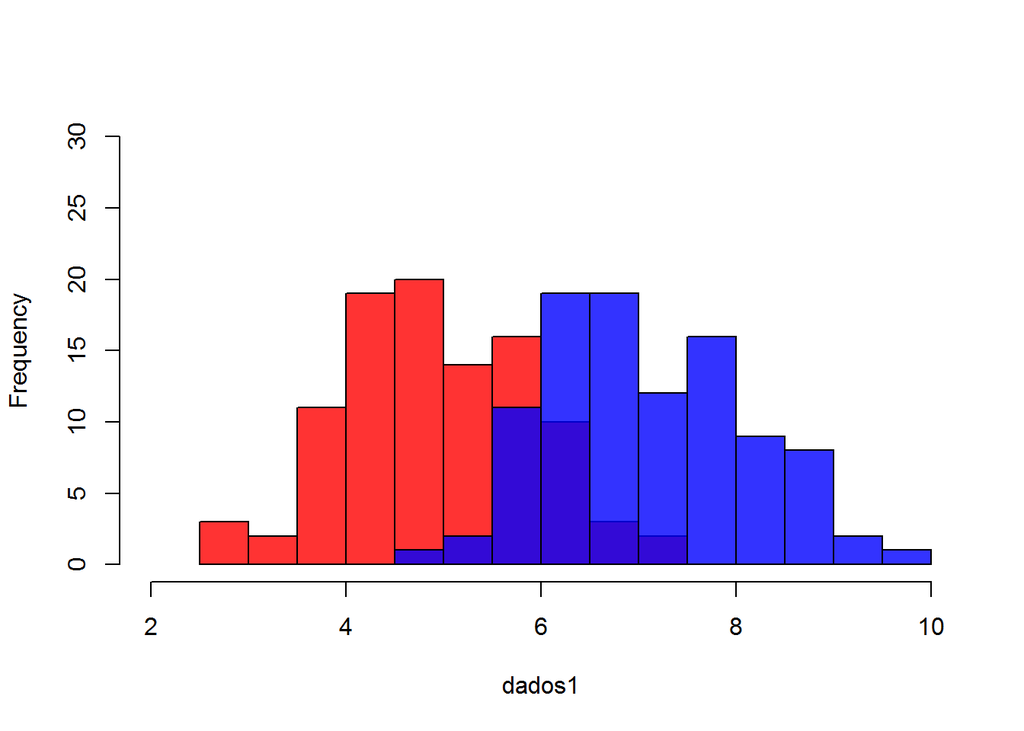

```r
library(scales)

hist(dados1, main=NULL, col=alpha("red", 0.8), xlim=c(2, 10), ylim=c(0, 30))
hist(dados2, main=NULL, col=alpha("blue", 0.8), add=T)
```

E aí é só brincar um pouquinho e encontrar o melhor estilo para o seu gráfico. ;)

*Bom, gente, por hoje é só. Espero que a função alpha possa ser útil para vocês no futuro. Pessoalmente, eu nunca a usei na prática em histogramas, mas ela já me ajudou bastante em gráficos de ordenação com polígonos (como em um NMDS, por exemplo).*

*Abraços, e até o próximo script!*

*Prof Marcos*